# Least Square Regression:

## Range Space Projection and Basis Functions

```python
%matplotlib inline
import numpy as np
from matplotlib import pyplot as plt
from scipy.optimize import minimize
from numpy.linalg import lstsq, solve
from numpy.random import seed, randn
seed(1234)
xs = np.linspace(-2,2,10)
ys = [np.sin(x) + randn()/8 for x in xs]
```

This tutorial involves using least squares to find best fit functions to a $sin$ plot with some noise added. To start, we will fit using a $\textit{Standard Basis Function: }c_0+c_1x+c_2x^2+...+c_nx^n$. For this example, we will use the first four terms, so that we may let matrix $A$ have column space $x^0,x^1,x^2,x^3$ and coefficient vector $\vec{c}=<a,b,c,d>$. Because the vector $\vec{c}$ has constants for elements, I've named them $a,b,c$ and $d$. The least squares fit for this standard cubic basis function is the projection of our data into the column space (range space) of $A$, which can be computed by solving $A^TA\vec{c}=A^T\vec{y}$. Below is an example of the solution to this linear system:

```python
A = np.vstack([xs**3, xs**2, xs**1, xs**0]).transpose()
solution = solve(A.transpose().dot(A), A.transpose().dot(ys))
print(A)
print('---------------------------------------------------')
print(solution,'|')
```

```
[[-8.          4.         -2.          1.        ]
 [-3.76406036  2.41975309 -1.55555556  1.        ]
 [-1.37174211  1.2345679  -1.11111111  1.        ]
 [-0.2962963   0.44444444 -0.66666667  1.        ]
 [-0.01097394  0.04938272 -0.22222222  1.        ]
 [ 0.01097394  0.04938272  0.22222222  1.        ]
 [ 0.2962963   0.44444444  0.66666667  1.        ]
 [ 1.37174211  1.2345679   1.11111111  1.        ]
 [ 3.76406036  2.41975309  1.55555556  1.        ]
 [ 8.          4.          2.          1.        ]]
---------------------------------------------------
(array([-0.15983975, -0.03854726,  1.01929962,  0.04485733]), '|')
```

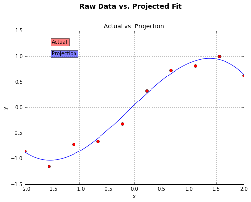

```python
#define matrix A with standard basis range space and dot it with x vector
A = np.vstack([xs**3, xs**2, xs**1, xs**0]).transpose()
coeffs = np.linalg.lstsq(A, ys)[0]#extract coeffs from lstq's poly1d output
p = np.poly1d(coeffs)#generate standard basis polynomial from coefficient vector

xxs = np.linspace(-2,2,100)#segment [-2,2] as 100 discrete points
yys = p(xxs)#generates y values for best fit poly


#
#Pretty pictures!!!!!!!!!!!!!!!!!!!!!!!!!!
#
fig=plt.figure() #creates figure object
fig.suptitle('Raw Data vs. Projected Fit', fontsize=14, fontweight='bold') #adds title layer


ax = fig.add_subplot(111) #add new subplot to figure
fig.subplots_adjust(top=0.85) #move down for subtitle
ax.set_title('Actual vs. Projection') #add subtitle
ax.set_xlabel('x')#x label
ax.set_ylabel('y') #y label
ax.text(-1.5, 1.25, 'Actual',
        bbox={'facecolor':'red', 'alpha':0.5, 'pad':2.55}) #add legend box for observed
ax.text(-1.5, 1.02, 'Projection',#alpha level is for transperency, 1 is opaque, 0 is transparent
        bbox={'facecolor':'blue', 'alpha':0.5, 'pad':2.55}) #add legend box for expected
ax.plot(xs,ys,'ro') #add data points for immigration ('ro' for red dots)
ax.plot(xxs,yys,'b') #add best fit line for Extinction
ax.grid()
fig.set_size_inches(8,6) #set figure size in inches


plt.show() #display figure
```

Next, we were to assume a $\textit{Chevyshev Basis: }c_0x^0,c_1x^1,c_2\left(2x^2-1\right),c_3\left(4x^3-3x\right)$. A $\textit{Chevyshev Basis}$ can converge more closely using fewer terms because each basis column is orthogonal to all other columns. A $\textit{Gram–Schmidt}$ process can be used to generate an infinite Chevyshev basis function, a process similar to generating a Fourier series. Another way to minimize error is to use the first derivative of the resulting system to find the minimum of the linear combinations of the matrix $A$. Scipy's `minimize` function returns a dictionary with an $x$ array containing the vector $\vec{c}$ at the minimum. Below, the function `squares` returns the sum of squared residuals. This is also known as an objective function:

```python
def squares(ab):#objective function
    a = ab[0]
    b = ab[1]      #extracts initial guess
    c = ab[2]      #
    d = ab[3]
    return sum([((a + b*xs[i]+c*(2*xs[i]**2-1)+d*(4*xs[i]**3-3*xs[i]))-ys[i])**2
                for i in range(len(xs))])#returns sum of squared residuals
result = minimize(squares,[.3,.3,.2,.1,])#minimizes objective function given initial guess
result#display results
```

```
      fun: 0.09492005716101454
 hess_inv: array([[  8.15770509e-02,  -8.51087490e-05,  -1.37911332e-02,
          6.97251065e-06],
       [ -8.51087490e-05,   1.27390165e-01,  -5.51015019e-06,
         -1.12720370e-02],
       [ -1.37911332e-02,  -5.51015019e-06,   6.08060349e-03,
          5.27884090e-07],
       [  6.97251065e-06,  -1.12720370e-02,   5.27884090e-07,
          1.31400292e-03]])
      jac: array([  1.00582838e-07,  -1.95577741e-08,   6.42612576e-08,
        -2.88709998e-08])
  message: 'Optimization terminated successfully.'
     nfev: 66
      nit: 9
     njev: 11
   status: 0
  success: True
        x: array([ 0.02558372,  0.89942004, -0.01927364, -0.03995997])
```

Which is the same as the projection $A^TA\vec{c}=A^T\vec{y}$ of our data into our new matrix $A$ with the Chevyshev basis:

```python
#define A with Chevyshev basis and dot with xs
A = np.vstack([np.ones(len(xs)),xs,2*xs**2-1,4*xs**3-3*xs]).transpose()
solution = solve(A.transpose().dot(A), A.transpose().dot(ys))#solve projection
print(A)
print('-------------------------------------------------------')
print(solution)
```

```
[[  1.          -2.           7.         -26.        ]
 [  1.          -1.55555556   3.83950617 -10.38957476]
 [  1.          -1.11111111   1.4691358   -2.15363512]
 [  1.          -0.66666667  -0.11111111   0.81481481]
 [  1.          -0.22222222  -0.90123457   0.62277092]
 [  1.           0.22222222  -0.90123457  -0.62277092]
 [  1.           0.66666667  -0.11111111  -0.81481481]
 [  1.           1.11111111   1.4691358    2.15363512]
 [  1.           1.55555556   3.83950617  10.38957476]
 [  1.           2.           7.          26.        ]]
-------------------------------------------------------
[ 0.02558369  0.8994198  -0.01927363 -0.03995994]
```

Here, we need to create our Chevyshev polynomial which I've named $chev$ for convenience, since ... I don't think... that there is a library function to produce y values for a Chevyshev polynomial.

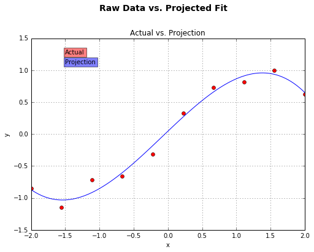

```python
a,b,c,d = result['x']#use result from scipy minimize
def chev(t):
    out=a + b*t +c*(2*t**2-1)+d*(4*t**3-3*t)#make my cubic chevyshev polynomial
    return out
xxs = np.linspace(-2,2,100)#[-2,2] as 100 discrete points with uniform spacing
yys = chev(xxs)#chevyshev poly function values

#
#More pretty pictures!!!!!!!!!!!!!
#
fig1=plt.figure() #creates figure object
fig1.suptitle('Raw Data vs. Projected Fit', fontsize=14, fontweight='bold') #adds title layer


ax = fig1.add_subplot(111) #add new subplot to figure
fig1.subplots_adjust(top=0.85) #move down for subtitle
ax.set_title('Actual vs. Projection') #add subtitle
ax.set_xlabel('x')#x label
ax.set_ylabel('y') #y label
ax.text(-1.5, 1.25, 'Actual',
        bbox={'facecolor':'red', 'alpha':0.5, 'pad':2.55}) #add legend box for observed
ax.text(-1.5, 1.1, 'Projection',                          #alpha level is for transperency, 1 is opaque, 0 is transparent
        bbox={'facecolor':'blue', 'alpha':0.5, 'pad':2.55}) #add legend box for expected
ax.plot(xs,ys,'ro') #add data points for immigration ('ro' for red dots)
ax.plot(xxs,yys,'b') #add best fit line for Extinction
ax.grid()
fig1.set_size_inches(8,6) #set figure size in inches


plt.show() #display figure
```